# R Notebook: introduction to classification (ideal with variants)

#### 1.1.2.1 Complex Plots

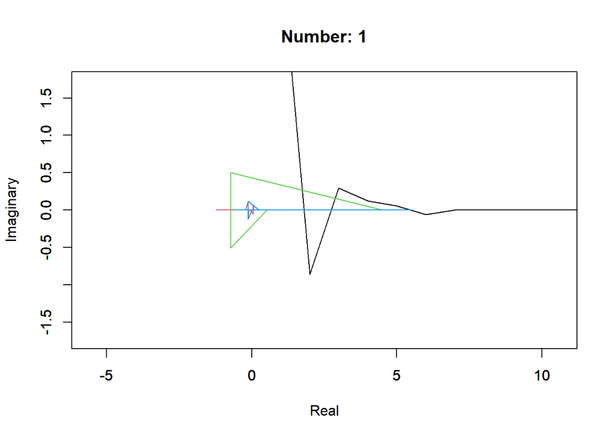

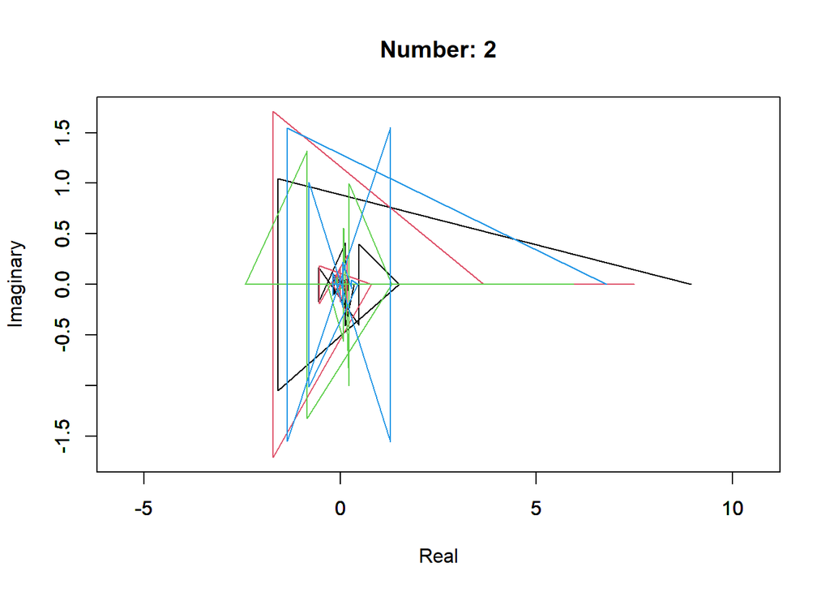

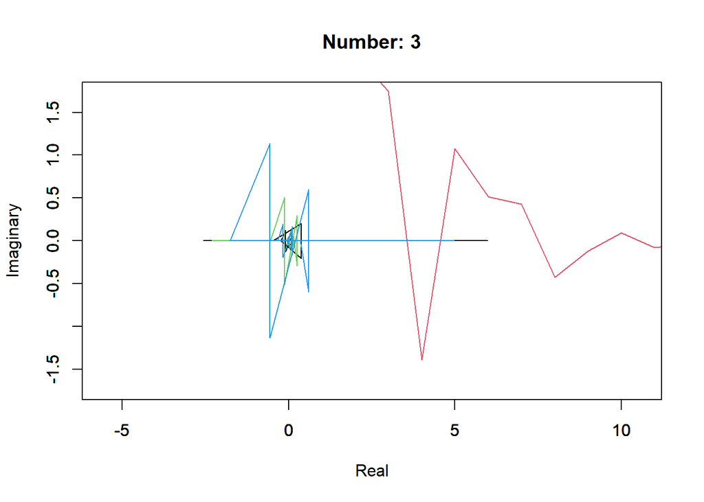

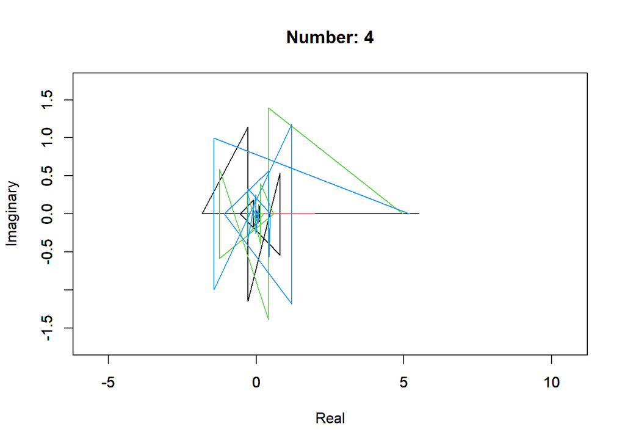

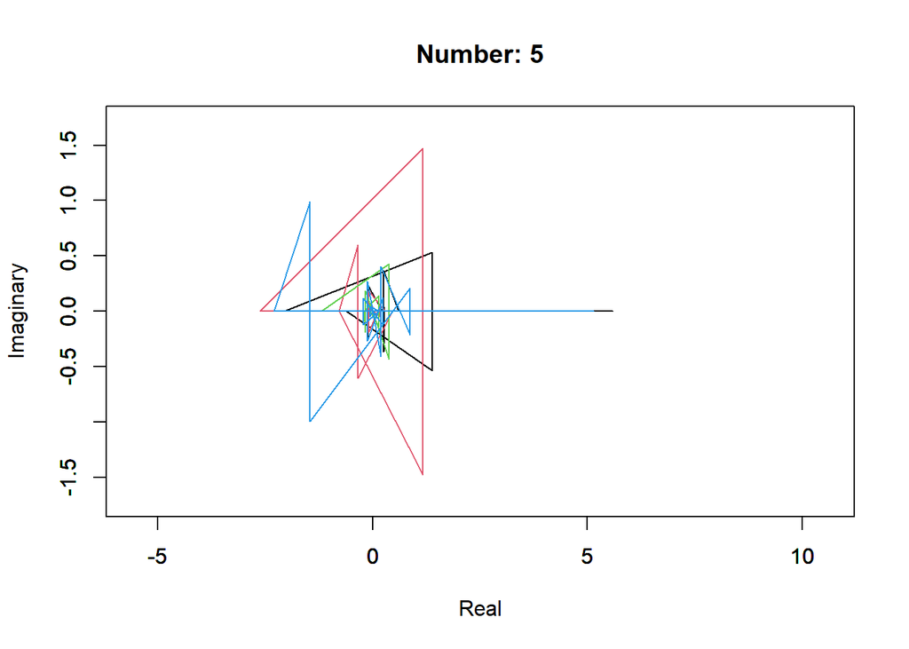

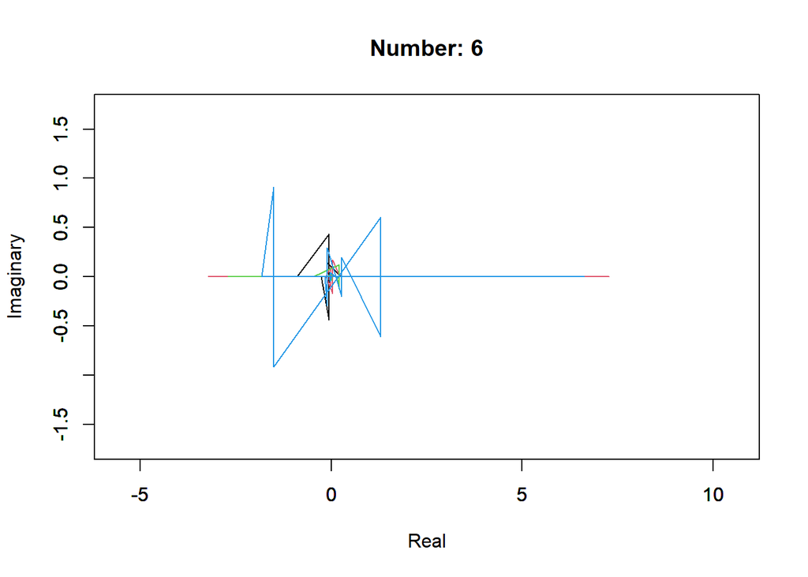

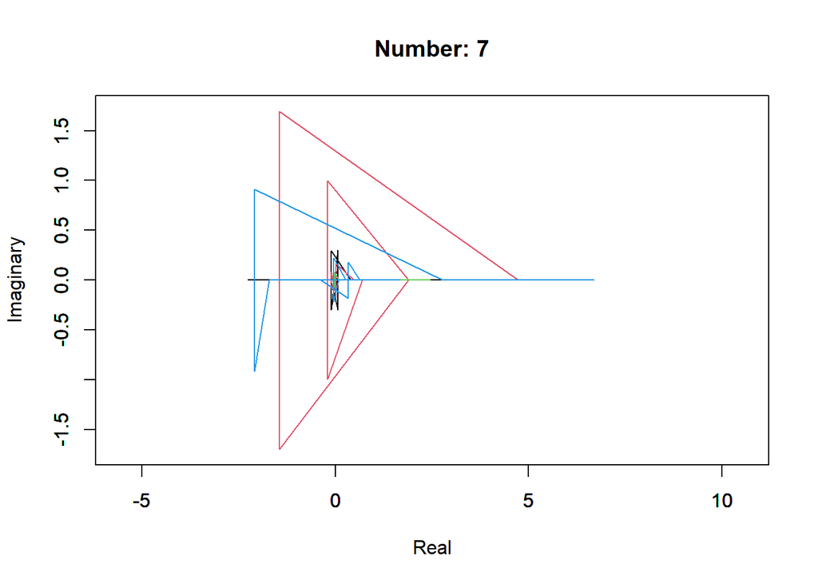

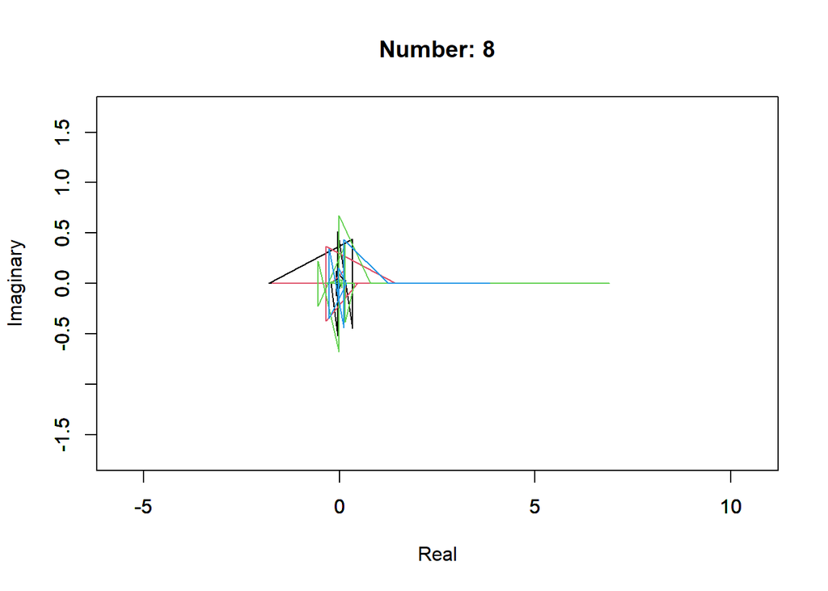

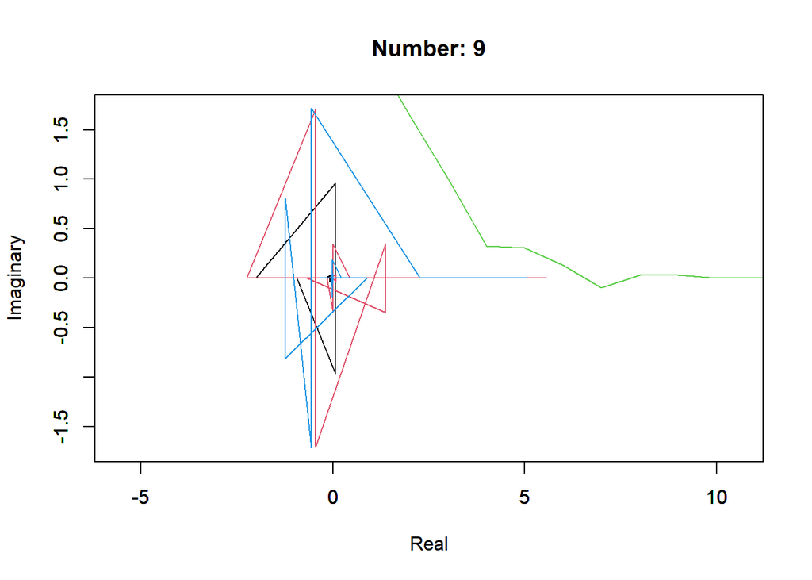

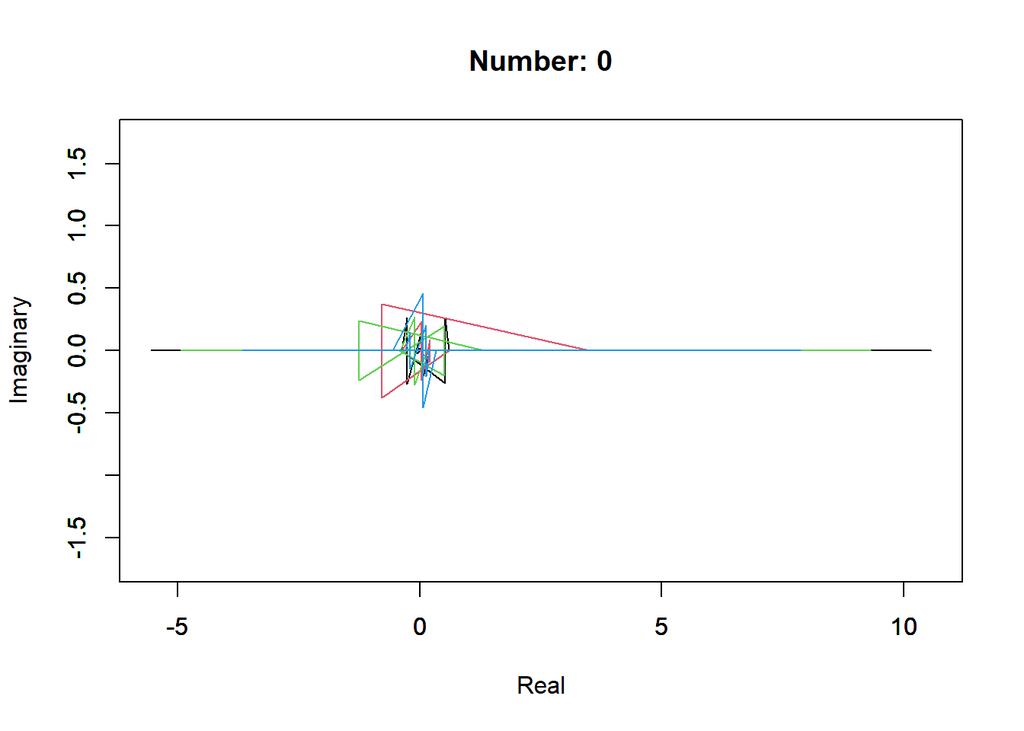

```r
# store in a matrix form
X.eigen = matrix(NA, nrow=28, ncol=10 * 4);
mycol = 1;
mynames = c();



maxx = 0; maxy = 0;
minx = 9999999; miny = 9999999;

# find global common scale ...
for(m in 1:10)
{
mynumber = m;
number = data$training[[mynumber]]$eigen;

  mymaxx = max(Re( unlist(number) ));
    if(mymaxx > maxx) { maxx = mymaxx; }
  myminx = min(Re( unlist(number) ));
    if(myminx < minx) { minx = myminx; }
  mymaxy = max(Im( unlist(number) ));
    if(mymaxy > maxy) { maxy = mymaxy; }
  myminy = min(Im( unlist(number) ));
    if(myminy < miny) { miny = myminy; }
}


for(m in 1:10)
{
mynumber = m;

number = data$training[[mynumber]]$eigen;
if(mynumber == 10) { mynumber = 0; } # for plotting
n = length(number);


for(i in 1:n)
  {
  mynames = c(mynames, paste0(mynumber,"-",letters[i]));
  X.eigen[,mycol] = number[[i]];
  mycol = 1 + mycol;
  ## COMPLEX PLOT
  if(i > 1)
    {


    par(new=TRUE);
    plot(number[[i]], xlab="", ylab="", type="l",
            xlim = c(minx,maxx), ylim = c(miny,maxy),
            col=palette()[i]
            );
    } else
        {
        plot(number[[i]], main=paste0("Number: ",mynumber),
            xlab="Real", ylab="Imaginary", type="l",
            xlim = c(minx,maxx), ylim = c(miny,maxy),
            col=palette()[i]
            );
        }
  }



}
```

```r
colnames(X.eigen) = mynames;
```

#### 1.1.2.2 Real Plots

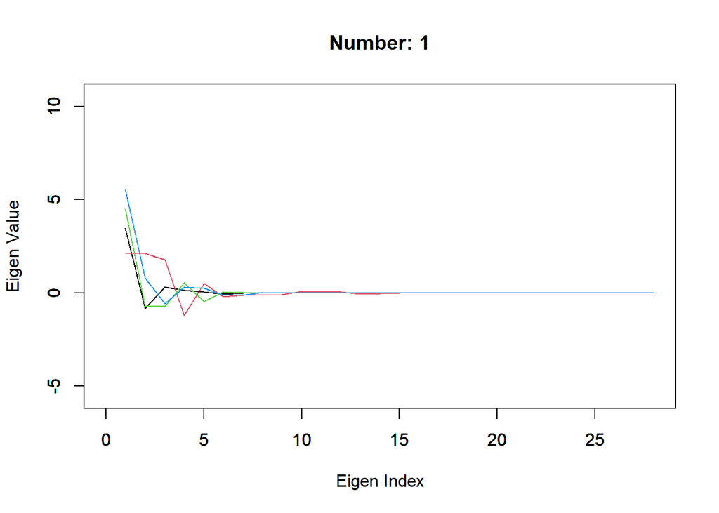

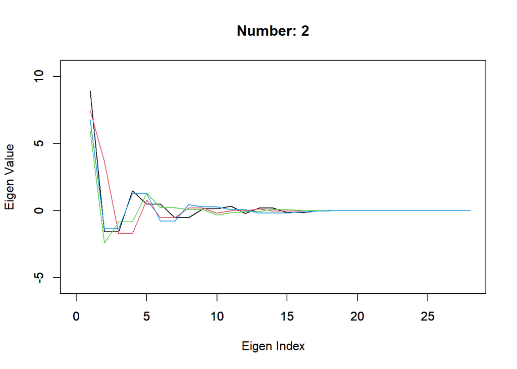

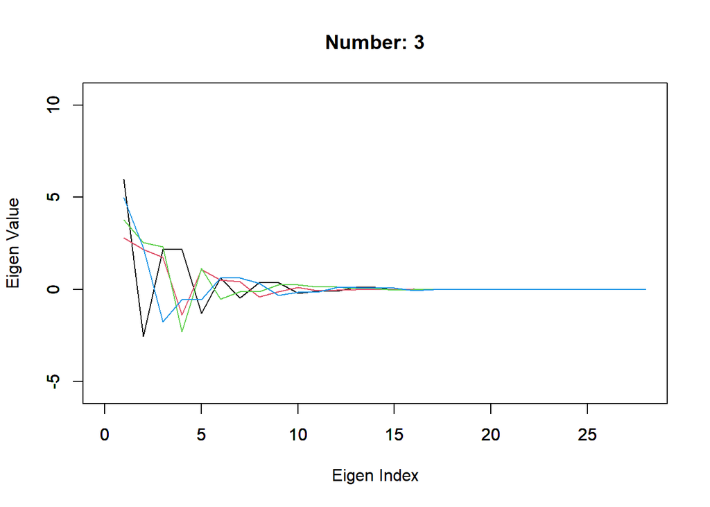

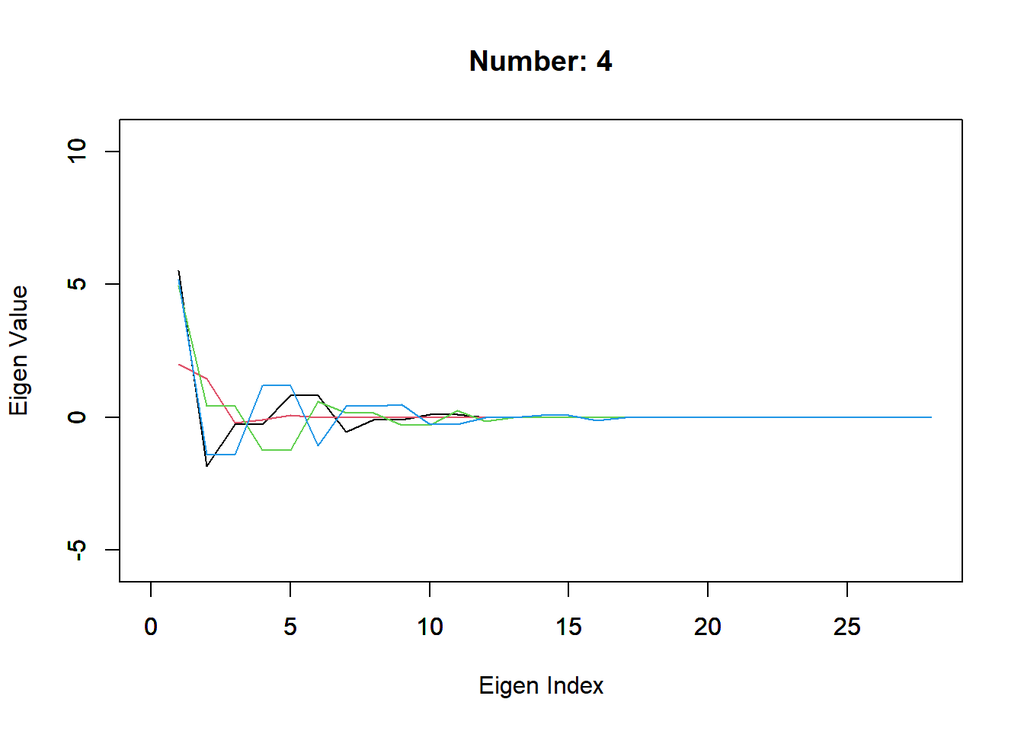

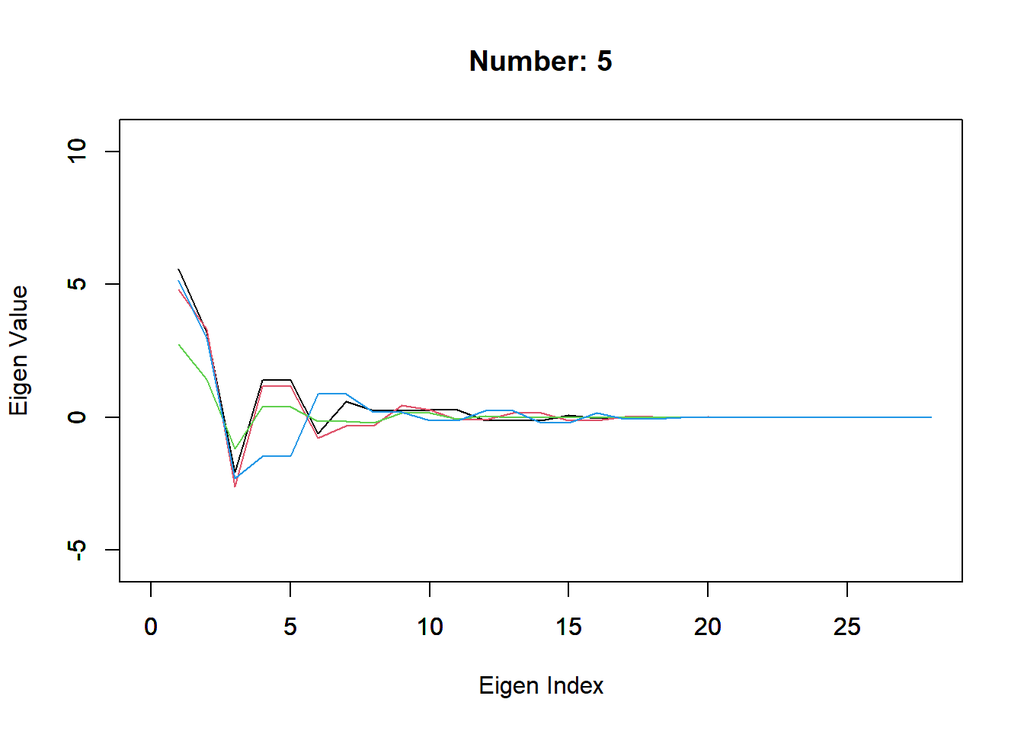

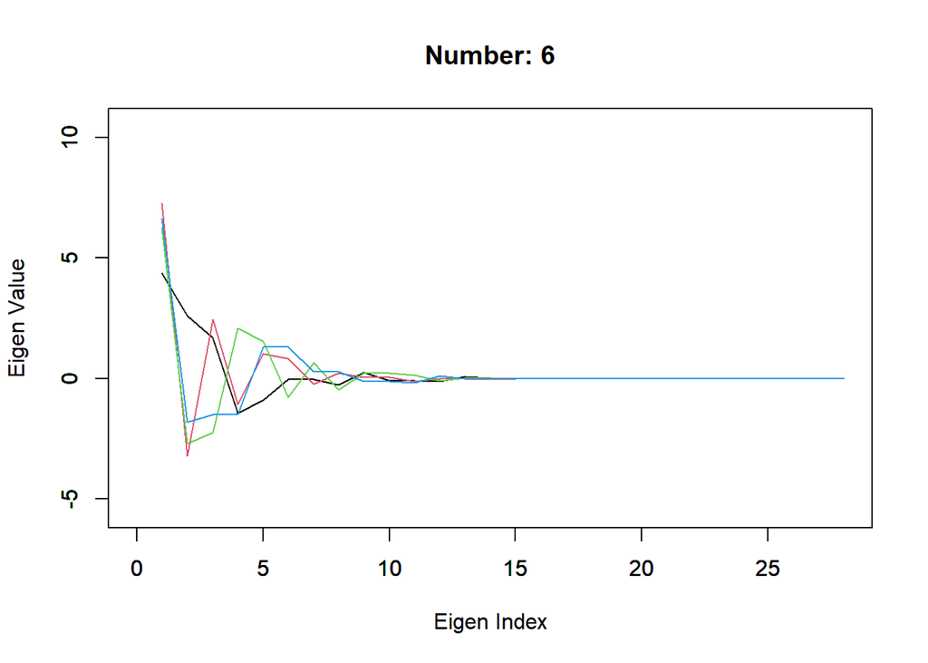

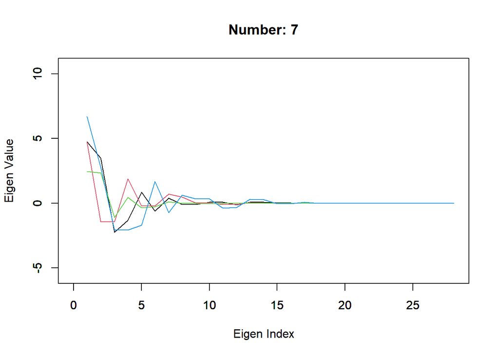

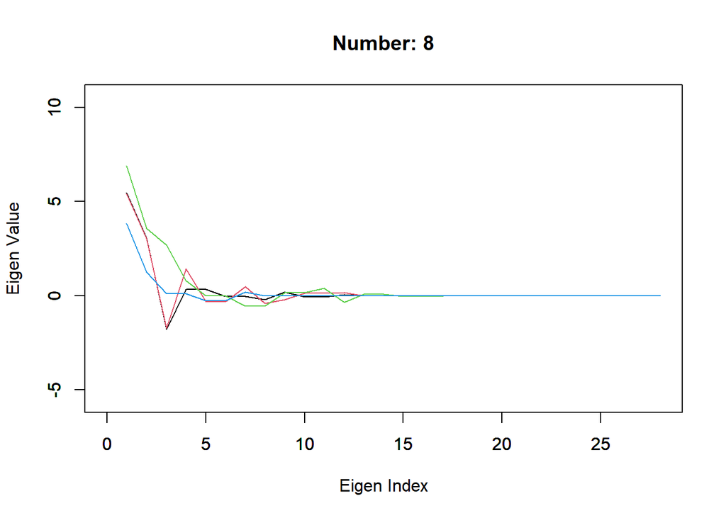

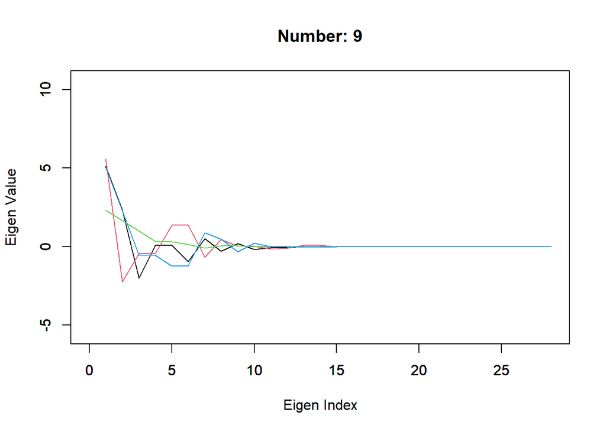

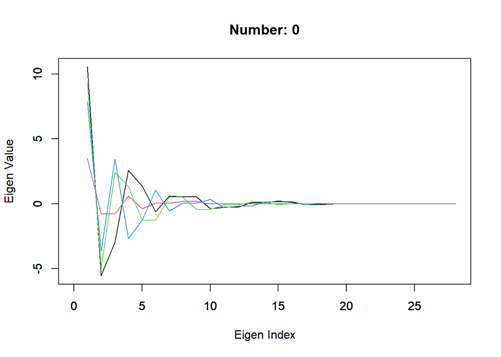

```r
for(m in 1:10)
{
mynumber = m;

number = data$training[[mynumber]]$eigen;
if(mynumber == 10) { mynumber = 0; } # for plotting
n = length(number);

## REAL PLOT
n.eigen = length( Re(number[[1]]) );
for(i in 1:n)
  {
  if(i > 1)
    {
    par(new=TRUE);
    plot(Re(number[[i]]), xlab="", ylab="", type="l",
            xlim = c(0,n.eigen), ylim = c(minx,maxx),
            col=palette()[i]
            );
    } else
        {
        plot(Re(number[[i]]), main=paste0("Number: ",mynumber),
            xlab="Eigen Index", ylab="Eigen Value", type="l",
            xlim = c(0,n.eigen), ylim = c(minx,maxx),
            col=palette()[i]
            );
        }
  }

}
```

### 1.1.3 Euclidean Distances

It should be emphasized we haven’t applied any “assumptions” about the nature of the data. We haven’t averaged all the sevens into one “common image and eigenvector” - we have just built a dictionary of unique sevens from our data. And when we review our data, we may notice that one variant of “one” may be closer to a variant of “seven” than any other of the “ones”. We will have to build a probability or likelihood model to pick the best. Not with our “training data”, we build these variants in intentionally specifically to help distinguish a one from a seven. Having more variants would help clarify this distinction.

```r
source_url( paste0(path.github,"humanVerseWSU/R/functions-EDA.R") );
```

```
## SHA-1 hash of file is 9a397c6d1f50caa6caad70bf01c17242731350b9
```

```r
do.nothing = perform.hclust( t(X.eigen), 8);
```

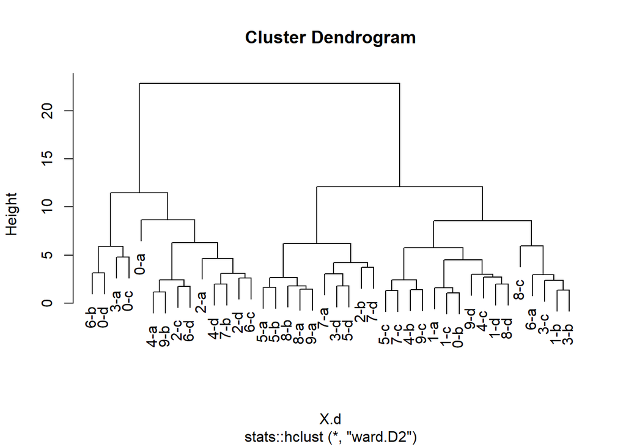

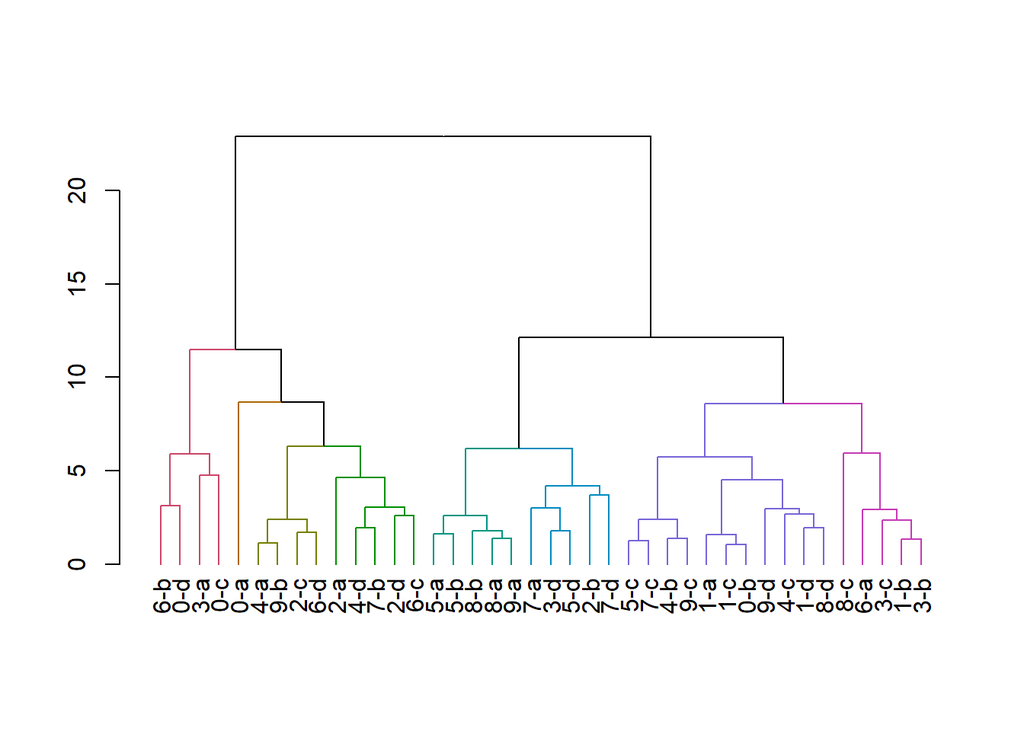

```
## [1] "Pruning 1 of 8"
## [1] "Pruning 2 of 8"
## [1] "Pruning 3 of 8"
## [1] "Pruning 4 of 8"
## [1] "Pruning 5 of 8"
## [1] "Pruning 6 of 8"
## [1] "Pruning 7 of 8"
## [1] "Pruning 8 of 8"
```

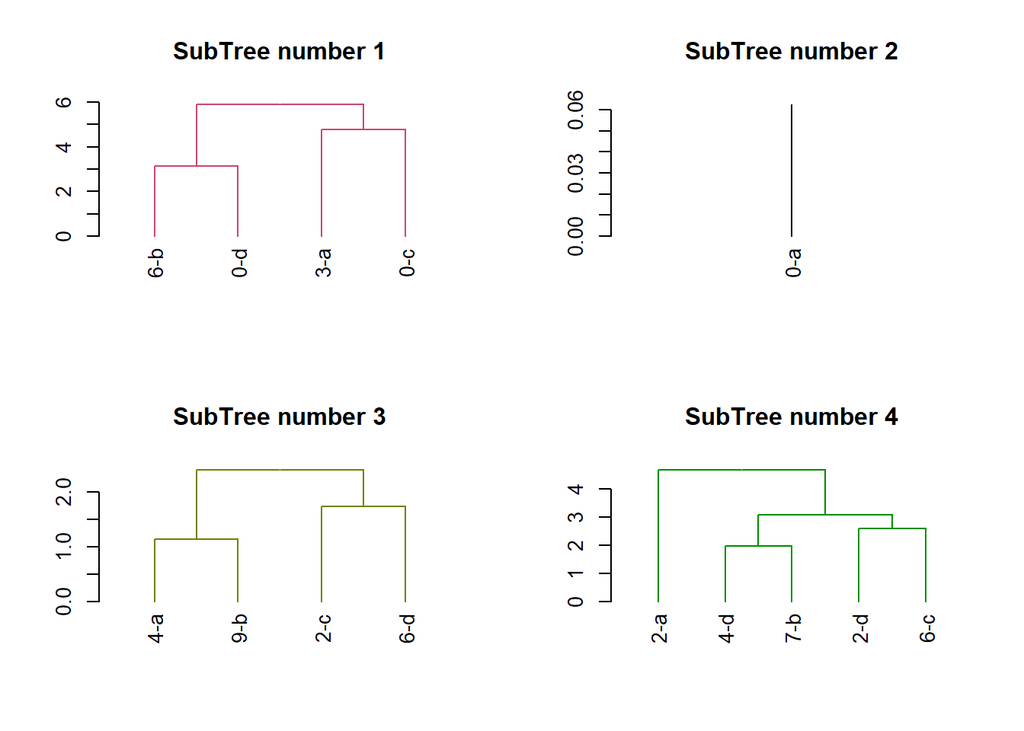

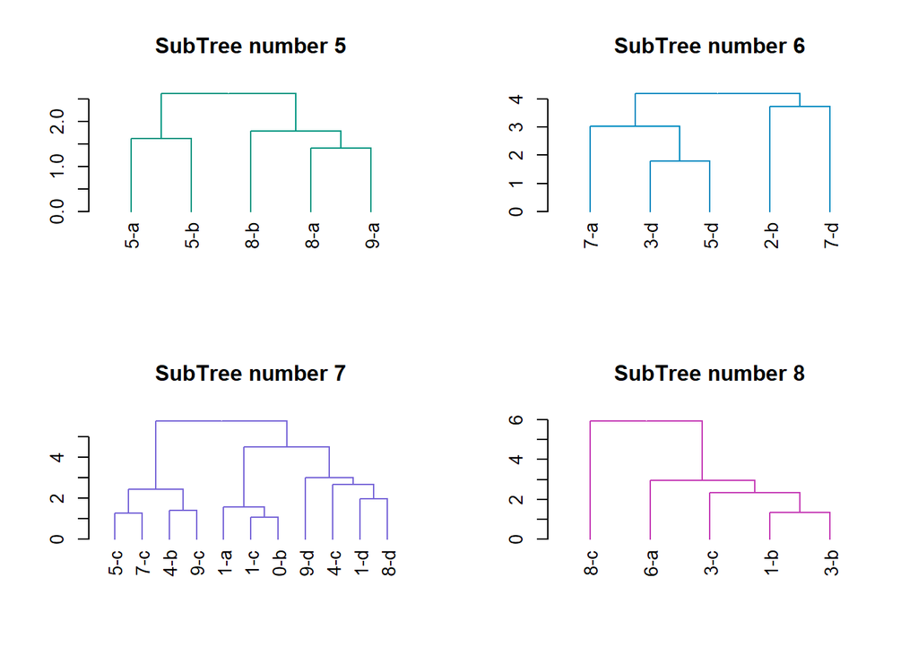

```r
X.eigen.d = stats::dist( t(X.eigen), method="euclidean");
```

```r
# library(tripack);
# plot(X.eigen.d);


X.eigen.df = as.data.frame( round( as.matrix(X.eigen.d), 2) );
  colnames(X.eigen.df) = rownames(X.eigen.df) = mynames;


X.eigen.df;
```

|  | 1-a | 1-b | 1-c | 1-d | 2-a | 2-b | 2-c | 2-d | 3-a | 3-b | 3-c | 3-d | 4-a | 4-b | 4-c | 4-d | 5-a | 5-b | 5-c | 5-d | 6-a | 6-b | 6-c | 6-d | 7-a | 7-b | 7-c | 7-d | 8-a | … |
| --- | --- | --- | --- | --- | --- | --- | --- | --- | --- | --- | --- | --- | --- | --- | --- | --- | --- | --- | --- | --- | --- | --- | --- | --- | --- | --- | --- | --- | --- | --- |
| 1-a | 0.00 | 3.87 | 1.62 | 2.80 | 6.13 | 6.73 | 3.58 | 4.31 | 4.47 | 3.97 | 4.83 | 4.26 | 2.71 | 2.80 | 2.86 | 3.25 | 5.57 | 5.59 | 2.88 | 5.58 | 4.26 | 5.31 | 5.01 | 4.53 | 5.50 | 3.01 | 3.68 | 6.48 | 4.91 | … |
| 1-b | 3.87 | 0.00 | 4.92 | 4.61 | 8.96 | 6.65 | 6.61 | 7.20 | 7.31 | 1.33 | 2.26 | 4.88 | 5.80 | 2.45 | 4.11 | 6.36 | 6.05 | 5.92 | 3.51 | 5.76 | 2.76 | 7.57 | 8.36 | 7.08 | 5.06 | 6.43 | 3.47 | 6.87 | 5.25 | … |
| 1-c | 1.62 | 4.92 | 0.00 | 2.00 | 4.92 | 6.04 | 3.21 | 3.40 | 4.28 | 4.91 | 5.64 | 3.50 | 2.39 | 3.47 | 2.67 | 2.59 | 4.88 | 4.94 | 2.99 | 4.83 | 4.59 | 5.45 | 4.16 | 3.92 | 5.09 | 1.96 | 3.72 | 5.62 | 4.16 | … |
| 1-d | 2.80 | 4.61 | 2.00 | 0.00 | 4.60 | 4.26 | 3.67 | 3.20 | 5.11 | 4.38 | 4.74 | 2.56 | 2.96 | 3.65 | 2.63 | 3.04 | 3.40 | 3.68 | 2.93 | 4.03 | 3.77 | 5.66 | 4.68 | 3.95 | 3.76 | 3.19 | 3.53 | 4.67 | 2.60 | … |
| 2-a | 6.13 | 8.96 | 4.92 | 4.60 | 0.00 | 6.48 | 4.25 | 2.95 | 5.37 | 8.55 | 8.71 | 6.22 | 4.18 | 7.97 | 6.00 | 4.48 | 6.23 | 6.69 | 7.08 | 7.20 | 7.79 | 5.48 | 3.70 | 4.21 | 7.38 | 4.68 | 7.82 | 6.75 | 6.01 | … |
| 2-b | 6.73 | 6.65 | 6.04 | 4.26 | 6.48 | 0.00 | 6.51 | 5.96 | 8.78 | 6.24 | 5.69 | 3.81 | 6.35 | 6.42 | 5.29 | 6.44 | 3.95 | 4.16 | 5.73 | 3.95 | 5.10 | 8.21 | 7.71 | 5.95 | 3.03 | 7.05 | 5.83 | 3.72 | 3.09 | … |
| 2-c | 3.58 | 6.61 | 3.21 | 3.67 | 4.25 | 6.51 | 0.00 | 3.09 | 5.10 | 6.23 | 6.56 | 5.27 | 1.65 | 5.80 | 4.22 | 2.87 | 6.31 | 6.60 | 5.33 | 6.43 | 6.29 | 3.79 | 3.57 | 1.73 | 6.30 | 3.66 | 6.31 | 6.63 | 5.83 | … |
| 2-d | 4.31 | 7.20 | 3.40 | 3.20 | 2.95 | 5.96 | 3.09 | 0.00 | 4.97 | 7.03 | 7.20 | 5.29 | 2.98 | 6.11 | 5.12 | 2.20 | 5.00 | 5.33 | 5.21 | 6.60 | 6.69 | 5.22 | 2.60 | 3.76 | 6.13 | 3.12 | 6.11 | 6.71 | 5.01 | … |
| 3-a | 4.47 | 7.31 | 4.28 | 5.11 | 5.37 | 8.78 | 5.10 | 4.97 | 0.00 | 7.28 | 7.70 | 7.02 | 4.23 | 6.78 | 5.07 | 5.09 | 7.91 | 8.29 | 6.72 | 8.18 | 6.62 | 4.31 | 5.66 | 6.01 | 8.80 | 4.41 | 7.25 | 8.20 | 7.41 | … |
| 3-b | 3.97 | 1.33 | 4.91 | 4.38 | 8.55 | 6.24 | 6.23 | 7.03 | 7.28 | 0.00 | 2.01 | 4.60 | 5.49 | 2.90 | 3.95 | 6.26 | 5.77 | 5.80 | 3.71 | 5.49 | 2.70 | 7.13 | 8.12 | 6.52 | 4.79 | 6.40 | 3.82 | 6.55 | 4.98 | … |

[output cut: 30 more lines]

```r
# 1-b and 9-c seem to be neighbors looking at the "distance table" ... visually, is that valid?  If I didn't have these two variants in the "training set" dictionary, I would find a "nearest neighbor" that was incorrect

# similar to the "hometown" issue, we have a data table of distances and can add one "test data" at a time, and find the nearest neighbor ...
```

### 1.1.4 Cosine Similarity

Our multivariate data is a vector space, so we can use “cosine similarity” to understand relationships among vectors. The result can be read similiar to a correlation. +1 is perfect similarity in the same direction. 0 is perfect dissimilarity (orthogonality). -1 is perfect similarity in the opposite direction. https://en.wikipedia.org/wiki/Cosine_similarity

```r
library(lsa);  # install.packages("lsa", dependencies=TRUE);
# cosine(x);
X.eigen.cos = as.data.frame( round( cosine(X.eigen),2 ) );  ## 40 x 40

# COMPLEX RESULT
X.eigen.cos;
```

|  | 1-a | 1-b | 1-c | 1-d | 2-a | 2-b | 2-c | 2-d | 3-a | 3-b | 3-c | 3-d | 4-a | 4-b | 4-c | 4-d | 5-a | 5-b | 5-c | 5-d | 6-a | 6-b | 6-c | 6-d | 7-a | 7-b | 7-c | 7-d | 8-a | … |
| --- | --- | --- | --- | --- | --- | --- | --- | --- | --- | --- | --- | --- | --- | --- | --- | --- | --- | --- | --- | --- | --- | --- | --- | --- | --- | --- | --- | --- | --- | --- |
| 1-a | 1.00+0.00i | 0.44+0.00i | 0.97-0.04i | 0.91+0.00i | 0.97-0.04i | 0.74+0.01i | 1.01+0.01i | 1.04-0.07i | 0.90+0.00i | 0.52+0.00i | 0.56+0.00i | 0.73+0.00i | 1.01+0.01i | 0.63+0.00i | 0.96-0.09i | 0.97-0.05i | 0.64+0.00i | 0.59+0.00i | 0.67+0.00i | 0.60+0.00i | 0.66+0.00i | 0.94+0.00i | 0.86+0.00i | 0.92+0.01i | 0.54+0.00i | 1.01-0.11i | 0.48+0.00i | 0.67+0.01i | 0.68+0.00i | … |
| 1-b | 0.44+0.00i | 1.00+0.00i | 0.34+0.01i | 0.58+0.00i | 0.32+0.02i | 0.74+0.16i | 0.33+0.17i | 0.35-0.10i | 0.27+0.00i | 0.96+0.01i | 0.98+0.00i | 0.60-0.10i | 0.38+0.18i | 0.76+0.00i | 0.70-0.03i | 0.22-0.08i | 0.54-0.03i | 0.50-0.11i | 0.53-0.06i | 0.56-0.07i | 0.91+0.00i | 0.46+0.00i | 0.07+0.00i | 0.36+0.11i | 0.64+0.00i | 0.10+0.07i | 0.56+0.00i | 0.58+0.08i | 0.61-0.03i | … |
| 1-c | 0.97-0.04i | 0.34+0.01i | 1.00+0.00i | 0.95+0.03i | 0.98+0.00i | 0.82+0.01i | 1.00-0.08i | 1.02+0.05i | 0.85-0.07i | 0.42+0.01i | 0.44+0.00i | 0.86+0.12i | 1.01-0.10i | 0.70+0.07i | 0.90+0.03i | 0.97+0.05i | 0.75+0.10i | 0.73+0.15i | 0.80+0.11i | 0.74+0.12i | 0.63+0.02i | 0.82-0.07i | 0.90-0.01i | 0.94-0.05i | 0.64+0.10i | 1.02-0.02i | 0.63+0.10i | 0.79+0.03i | 0.79+0.10i | … |
| 1-d | 0.91+0.00i | 0.58+0.00i | 0.95+0.03i | 1.00+0.00i | 0.95+0.03i | 0.95-0.03i | 0.89-0.03i | 1.03+0.06i | 0.72+0.00i | 0.64+0.00i | 0.66+0.00i | 0.95+0.00i | 0.92-0.02i | 0.88+0.00i | 0.98+0.07i | 0.95+0.04i | 0.89+0.00i | 0.89+0.00i | 0.92+0.00i | 0.83+0.00i | 0.78+0.00i | 0.75+0.00i | 0.80+0.00i | 0.88-0.01i | 0.82+0.00i | 0.97+0.10i | 0.79+0.00i | 0.85-0.01i | 0.93+0.00i | … |
| 2-a | 0.97-0.04i | 0.32+0.02i | 0.98+0.00i | 0.95+0.03i | 1.00+0.00i | 0.82+0.01i | 1.04-0.08i | 1.08+0.06i | 0.84-0.08i | 0.43+0.02i | 0.43+0.02i | 0.84+0.10i | 1.03-0.10i | 0.68+0.08i | 0.84+0.00i | 1.00+0.05i | 0.78+0.10i | 0.77+0.15i | 0.82+0.12i | 0.69+0.09i | 0.58+0.02i | 0.83-0.08i | 0.94+0.01i | 0.94-0.05i | 0.64+0.10i | 1.00+0.00i | 0.61+0.11i | 0.75+0.01i | 0.80+0.11i | … |
| 2-b | 0.74+0.01i | 0.74+0.16i | 0.82+0.01i | 0.95-0.03i | 0.82+0.01i | 1.00+0.00i | 0.66+0.00i | 0.96+0.00i | 0.44+0.00i | 0.77+0.14i | 0.82+0.16i | 1.07-0.10i | 0.67+0.02i | 1.00-0.01i | 1.04+0.22i | 0.86-0.06i | 0.96-0.13i | 1.04-0.21i | 1.02-0.14i | 0.99-0.07i | 0.87+0.11i | 0.57+0.09i | 0.59-0.12i | 0.75+0.02i | 1.01-0.03i | 0.79+0.12i | 0.92-0.09i | 0.91+0.01i | 1.02-0.09i | … |
| 2-c | 1.01+0.01i | 0.33+0.17i | 1.00-0.08i | 0.89-0.03i | 1.04-0.08i | 0.66+0.00i | 1.00+0.00i | 1.16-0.22i | 0.79+0.02i | 0.46+0.15i | 0.52+0.16i | 0.75-0.11i | 1.02+0.05i | 0.56-0.01i | 1.03-0.01i | 1.17-0.27i | 0.64-0.16i | 0.66-0.23i | 0.69-0.15i | 0.62-0.08i | 0.51+0.11i | 0.97+0.11i | 0.96-0.16i | 1.05+0.05i | 0.58-0.06i | 1.15-0.22i | 0.40-0.11i | 0.64+0.05i | 0.66-0.10i | … |
| 2-d | 1.04-0.07i | 0.35-0.10i | 1.02+0.05i | 1.03+0.06i | 1.08+0.06i | 0.96+0.00i | 1.16-0.22i | 1.00+0.00i | 0.87-0.02i | 0.43-0.11i | 0.50-0.16i | 0.71+0.17i | 1.23-0.12i | 0.72+0.14i | 0.72+0.00i | 1.03-0.06i | 0.84+0.15i | 0.76+0.19i | 0.82+0.19i | 0.59+0.19i | 0.55+0.02i | 0.90-0.20i | 1.06-0.02i | 1.10-0.11i | 0.70+0.11i | 1.12+0.14i | 0.64+0.26i | 0.78+0.13i | 0.80+0.18i | … |
| 3-a | 0.90+0.00i | 0.27+0.00i | 0.85-0.07i | 0.72+0.00i | 0.84-0.08i | 0.44+0.00i | 0.79+0.02i | 0.87-0.02i | 1.00+0.00i | 0.32+0.00i | 0.34-0.01i | 0.49+0.11i | 0.86-0.03i | 0.40+0.00i | 0.81-0.13i | 0.80-0.03i | 0.41+0.04i | 0.33+0.10i | 0.43+0.07i | 0.35+0.07i | 0.52+0.01i | 0.87+0.00i | 0.72+0.00i | 0.69-0.02i | 0.21+0.00i | 0.93-0.27i | 0.28+0.00i | 0.46+0.00i | 0.45+0.04i | … |
| 3-b | 0.52+0.00i | 0.96+0.01i | 0.42+0.01i | 0.64+0.00i | 0.43+0.02i | 0.77+0.14i | 0.46+0.15i | 0.43-0.11i | 0.32+0.00i | 1.00+0.00i | 0.97+0.01i | 0.67-0.11i | 0.50+0.15i | 0.79+0.00i | 0.76-0.03i | 0.33-0.08i | 0.59-0.05i | 0.55-0.11i | 0.59-0.07i | 0.62-0.09i | 0.89+0.00i | 0.55+0.00i | 0.19+0.00i | 0.51+0.10i | 0.68+0.00i | 0.22+0.06i | 0.56+0.00i | 0.63+0.08i | 0.66-0.04i | … |

[output cut: 30 more lines]

```r
X.eigen.cos = as.data.frame( round( cosine(Re(X.eigen)),2 ) );  ## 40 x 40

# REAL RESULT
X.eigen.cos;
```

|  | 1-a | 1-b | 1-c | 1-d | 2-a | 2-b | 2-c | 2-d | 3-a | 3-b | 3-c | 3-d | 4-a | 4-b | 4-c | 4-d | 5-a | 5-b | 5-c | 5-d | 6-a | 6-b | 6-c | 6-d | 7-a | 7-b | 7-c | 7-d | 8-a | … |
| --- | --- | --- | --- | --- | --- | --- | --- | --- | --- | --- | --- | --- | --- | --- | --- | --- | --- | --- | --- | --- | --- | --- | --- | --- | --- | --- | --- | --- | --- | --- |
| 1-a | 1.00 | 0.44 | 0.96 | 0.91 | 0.95 | 0.71 | 0.93 | 0.93 | 0.90 | 0.52 | 0.55 | 0.70 | 0.96 | 0.63 | 0.87 | 0.89 | 0.64 | 0.55 | 0.66 | 0.58 | 0.65 | 0.94 | 0.86 | 0.90 | 0.54 | 0.87 | 0.48 | 0.66 | 0.68 | … |
| 1-b | 0.44 | 1.00 | 0.33 | 0.58 | 0.32 | 0.71 | 0.30 | 0.31 | 0.27 | 0.96 | 0.98 | 0.56 | 0.36 | 0.76 | 0.64 | 0.21 | 0.53 | 0.48 | 0.52 | 0.54 | 0.90 | 0.46 | 0.07 | 0.35 | 0.64 | 0.09 | 0.56 | 0.57 | 0.60 | … |
| 1-c | 0.96 | 0.33 | 1.00 | 0.94 | 0.98 | 0.76 | 0.90 | 0.94 | 0.84 | 0.42 | 0.43 | 0.80 | 0.93 | 0.69 | 0.87 | 0.91 | 0.73 | 0.68 | 0.77 | 0.71 | 0.62 | 0.81 | 0.89 | 0.89 | 0.63 | 0.94 | 0.62 | 0.76 | 0.78 | … |
| 1-d | 0.91 | 0.58 | 0.94 | 1.00 | 0.94 | 0.92 | 0.84 | 0.91 | 0.72 | 0.64 | 0.65 | 0.90 | 0.87 | 0.88 | 0.89 | 0.86 | 0.88 | 0.84 | 0.91 | 0.81 | 0.78 | 0.75 | 0.80 | 0.85 | 0.82 | 0.84 | 0.79 | 0.84 | 0.92 | … |
| 2-a | 0.95 | 0.32 | 0.98 | 0.94 | 1.00 | 0.75 | 0.92 | 0.97 | 0.82 | 0.42 | 0.43 | 0.76 | 0.95 | 0.67 | 0.81 | 0.93 | 0.75 | 0.70 | 0.79 | 0.65 | 0.56 | 0.82 | 0.93 | 0.90 | 0.63 | 0.93 | 0.60 | 0.72 | 0.77 | … |
| 2-b | 0.71 | 0.71 | 0.76 | 0.92 | 0.75 | 1.00 | 0.68 | 0.74 | 0.42 | 0.74 | 0.77 | 0.94 | 0.69 | 0.96 | 0.83 | 0.68 | 0.90 | 0.89 | 0.93 | 0.90 | 0.84 | 0.55 | 0.57 | 0.74 | 0.96 | 0.60 | 0.88 | 0.91 | 0.96 | … |
| 2-c | 0.93 | 0.30 | 0.90 | 0.84 | 0.92 | 0.68 | 1.00 | 0.91 | 0.74 | 0.43 | 0.45 | 0.66 | 0.97 | 0.52 | 0.78 | 0.90 | 0.58 | 0.52 | 0.62 | 0.55 | 0.49 | 0.90 | 0.89 | 0.98 | 0.55 | 0.84 | 0.37 | 0.63 | 0.61 | … |
| 2-d | 0.93 | 0.31 | 0.94 | 0.91 | 0.97 | 0.74 | 0.91 | 1.00 | 0.77 | 0.38 | 0.43 | 0.70 | 0.92 | 0.64 | 0.72 | 0.97 | 0.76 | 0.72 | 0.78 | 0.57 | 0.50 | 0.79 | 0.94 | 0.87 | 0.62 | 0.92 | 0.57 | 0.64 | 0.75 | … |
| 3-a | 0.90 | 0.27 | 0.84 | 0.72 | 0.82 | 0.42 | 0.74 | 0.77 | 1.00 | 0.32 | 0.34 | 0.46 | 0.82 | 0.40 | 0.73 | 0.73 | 0.41 | 0.31 | 0.42 | 0.34 | 0.51 | 0.86 | 0.72 | 0.67 | 0.21 | 0.80 | 0.28 | 0.46 | 0.44 | … |
| 3-b | 0.52 | 0.96 | 0.42 | 0.64 | 0.42 | 0.74 | 0.43 | 0.38 | 0.32 | 1.00 | 0.96 | 0.63 | 0.47 | 0.79 | 0.69 | 0.30 | 0.59 | 0.52 | 0.57 | 0.60 | 0.88 | 0.55 | 0.19 | 0.49 | 0.68 | 0.19 | 0.56 | 0.62 | 0.65 | … |

[output cut: 30 more lines]

### 1.1.5 Testing Data

So we have our computations completed in the “training” stage, let’s now apply to the “testing data.” **NOTE:** normally we don’t know the correct answer, that is screen from us. In this case we will use an internal “nearest to a number” approach to develop a solution. It is often that one splits the “training” data into two subsets to do some algorithm testing with one half using the other half as a temporary “training” set.

| variant | 1 | 2 | 3 | 4 | 5 | 6 | 7 | 8 | 9 | 0 |
| --- | --- | --- | --- | --- | --- | --- | --- | --- | --- | --- |
| a |  |  |  |  |  |  |  |  |  |  |
| b |  |  |  |  |  |  |  |  |  |  |
| c |  |  |  |  |  |  |  |  |  |  |
| d |  |  |  |  |  |  |  |  |  |  |
| e |  |  |  |  |  |  |  |  |  |  |
| f |  |  |  |  |  |  |  |  |  |  |
| g |  |  |  |  |  |  |  |  |  |  |
| h |  |  |  |  |  |  |  |  |  |  |
| i |  |  |  |  |  |  |  |  |  |  |
| j |  |  |  |  |  |  |  |  |  |  |
| k |  |  |  |  |  |  |  |  |  |  |
| l |  |  |  |  |  |  |  |  |  |  |

#### 1.1.5.1 Let’s start with zero `0-c`

```r
myfile = myfiles$testing[[10]][3];  # remember 0 is index 10

img.png = paste0(path.to.nascent,myfile);
img.matrix = getMatrixFromImage(img.png);
img.eigen = Re( eigen(img.matrix)$values );

## Let's use REAL only
compare = round( cosine( Re(img.eigen), Re(X.eigen) ), 2);
compare.matrix = matrix(compare, ncol=4, byrow=TRUE);

rownames(compare.matrix) = c(1:9,0);
colnames(compare.matrix) = letters[1:4];


compare.df = as.data.frame(compare.matrix);

## we want to find the top-1, so let's do that first
computeTop = function(df,howmany=10,method="sum")
  {
  df = as.matrix(df);  # abs( if we have negative values?
  df.sort = sort( unique(as.numeric(df)),
              decreasing=TRUE)[1:howmany];

  ndf = df;
  ndf[ ndf[,1:4] < df.sort[howmany] ] = 0;

  if(method == "sum") { return (rowSums(ndf)); }
  }

compare.df$top1  = computeTop(compare.df[,1:4], 1, "sum");



# we can look at some pooling features, using mean
compare.df$mean = rowMeans(compare.df[,1:4]);

# we can look at some pooling features, using median
rowMedians = function(df,method="default")
  {
  df = as.matrix(df);
  #print(df);
  rs = nrow(df);
  res = c();
  for(r in 1:rs)
    {
    xx = na.omit(df[r,]);
    #print(xx);
    if(method=="default")
      {
      m = median(xx);
      } else {
              m = as.numeric( stats::quantile(xx,
                              prob=c(0.5), type=1));
              }
    #print(paste0("r: ",r," --> ",m));
    res = c(res,m);
    }

  res;
  }

compare.df$median =  rowMedians(compare.df[,1:4],"default");



compare.df;
```

|  | a | b | c | d | top1 | mean | median |
| --- | --- | --- | --- | --- | --- | --- | --- |
| 1 | 0.86 | 0.03 | 0.94 | 0.80 | 0.00 | 0.6575 | 0.830 |
| 2 | 0.93 | 0.57 | 0.86 | 0.88 | 0.00 | 0.8100 | 0.870 |
| 3 | 0.77 | 0.16 | 0.15 | 0.67 | 0.00 | 0.4375 | 0.415 |
| 4 | 0.87 | 0.48 | 0.70 | 0.89 | 0.00 | 0.7350 | 0.785 |
| 5 | 0.61 | 0.57 | 0.66 | 0.59 | 0.00 | 0.6075 | 0.600 |
| 6 | 0.36 | 0.70 | 0.92 | 0.85 | 0.00 | 0.7075 | 0.775 |
| 7 | 0.48 | 0.95 | 0.48 | 0.63 | 0.00 | 0.6350 | 0.555 |
| 8 | 0.63 | 0.66 | 0.45 | 0.68 | 0.00 | 0.6050 | 0.645 |
| 9 | 0.68 | 0.83 | 0.34 | 0.60 | 0.00 | 0.6125 | 0.640 |
| 0 | 0.94 | 0.96 | 0.80 | 0.64 | 0.96 | 0.8350 | 0.870 |

It is worth noting a few things: - For this small data (4 elements per number), the mean and standard “median” are performing in tandem. - Given the nature of the eigenvector, the number `2` seems to perform about as well as the `0` … **about** but even with only four data points, the `0` slightly outperforms. - Notice at this point, I am thinking about “means” and “medians” because I am trying to ascertain which is the best map. We will then let “assymptotics” and other assumptions enter into the logical framework as we think about probabilities. - Truncating to get the “nearest neighbors” and computing a “median” or “mean” or “sum” will work as a nice isolator. - `Top-1` may be the only rule we need. We could test this.

```r
# we could create a weighted index of several statistical factors.  Let's just "add them up" (equally weighted) and pick the max ...
ncs = ncol(compare.df);

decide = rowSums(compare.df[,5:ncs]);
# could we get ties here?
decide.max.idx = whichMax(decide);


decide;
```

```
##      1      2      3      4      5      6      7      8      9      0
## 1.4875 1.6800 0.8525 1.5200 1.2075 1.4825 1.1900 1.2500 1.2525 2.6650
```

```r
decide.max.idx;
```

```
## [1] 10
```

```r
names(decide)[decide.max.idx];
```

```
## [1] "0"
```

#### 1.1.5.2 Function to Perform All

```r
# let's loop over the data, and store the "truth" with decisions based on various independent and joint rules ...

# wrap above code into a single function
predictDigit = function(myfile, X.eigen)
  {
  img.png = paste0(path.to.nascent,myfile);
  img.matrix = getMatrixFromImage(img.png);
  img.eigen = Re( eigen(img.matrix)$values );

  ## Let's use REAL only
  compare = round( cosine( Re(img.eigen), Re(X.eigen) ), 2);
  compare.matrix = matrix(compare, ncol=4, byrow=TRUE);

  rownames(compare.matrix) = c(1:9,0);
  colnames(compare.matrix) = letters[1:4];


  compare.df = as.data.frame(compare.matrix);
  compare.df$top1  = computeTop(compare.df[,1:4], 1, "sum");
  compare.df$mean = rowMeans(compare.df[,1:4]);
  compare.df$median =  rowMedians(compare.df[,1:4],"default");

  ncs = ncol(compare.df);
  decide = rowSums(compare.df[,5:ncs]);
  # could we get ties here?
  decide.max.idx = whichMax(decide);

  # for ties, we will let "which.max" decide

  list( "mean" = as.numeric(which.max(compare.df[,6])),
        "median" = as.numeric(which.max(compare.df[,7])),
        "top1" = as.numeric(which.max(compare.df[,5])),
        "sum3" = decide.max.idx[1]);
  }

performClassification = function(myfiles, X.eigen)
  {
  n = length(myfiles$testing);
  m = length(myfiles$testing[[1]]); # we assume equal length

  total = n * m;
  # algos:  mean, median, top-1, [all-3] ... 4
  result = matrix(NA, nrow=total, ncol=5);
  colnames(result) = c("true", "mean", "median", "top1", "sum3");


  i = 1;
  for(d in 1:n) # true digit
    {
    for(r in 1:m) # replicate
      {
      myfile = myfiles$testing[[d]][r];  # remember 0 is index 10
      res = predictDigit(myfile,X.eigen);

      row = c(d, unlist(res));
      result[i,] = row;
      i = 1 + i;

      }

    }


  result;
  }


result = as.data.frame( performClassification(myfiles,X.eigen) );
result;
```

| true | mean | median | top1 | sum3 |
| --- | --- | --- | --- | --- |
| 1 | 2 | 1 | 1 | 1 |
| 1 | 10 | 1 | 1 | 1 |
| 1 | 8 | 8 | 8 | 8 |
| 1 | 8 | 8 | 8 | 8 |
| 1 | 2 | 1 | 1 | 1 |
| 1 | 2 | 1 | 1 | 1 |
| 1 | 2 | 1 | 1 | 1 |
| 1 | 8 | 8 | 8 | 8 |
| 1 | 10 | 2 | 1 | 1 |
| 1 | 10 | 1 | 1 | 1 |

[output cut: 110 more lines]

##### 1.1.5.2.1 Review of Mean

```r
library(DescTools);
percent.mean = sum(result$true == result$mean) / nrow(result); # percentage correct %
percent.mean;
```

```
## [1] 0.2166667
```

```r
# CONFUSION MATRIX
# Conf(x = result$true, ref = result$mean);
```

##### 1.1.5.2.2 Review of Median

```r
library(DescTools);

percent.median = sum(result$true == result$median) / nrow(result); # percentage correct %
percent.median;
```

```
## [1] 0.275
```

```r
# CONFUSION MATRIX
# Conf(x = result$true, ref = result$median);
```

##### 1.1.5.2.3 Review of Top1

```r
library(DescTools);

percent.top1 = sum(result$true == result$top1) / nrow(result); # percentage correct %
percent.top1;
```

```
## [1] 0.2583333
```

```r
# CONFUSION MATRIX
# Conf(x = result$true, ref = result$top1);
```

##### 1.1.5.2.4 Review of Sum3

```r
library(DescTools);

percent.sum3 = sum(result$true == result$sum3) / nrow(result); # percentage correct %
percent.sum3;
```

```
## [1] 0.2916667
```

```r
# CONFUSION MATRIX
# Conf(x = result$true, ref = result$sum3, pos=10);
```

#### 1.1.5.3 Summary of Results

```r
percents = c(percent.mean, percent.median, percent.top1, percent.sum3);

percents;
```

```
## [1] 0.2166667 0.2750000 0.2583333 0.2916667
```

### 1.1.6 Can you do better?

This notebook demonstrates the process of how classification can play out. The algorithm in its current form is performing “sub-par” and you should comment above about why you think that is the case.

- Can you improve on the current performance by tweaking the existing algorithm with the existing data?
- Should we truncate the eigenvalues from 28 and remove all of the “zeroes” … is that creating a problem?

## 1.2 Conclusion

This shows how “eigen” can be used as a unique fingerprint of a matrix. This approach is commonly used, where the variants are increased tremendously. A full “basis space” is built for each digit’s variant database.

### 1.2.1 Sub-eigens

An approach based on eigen that I will discuss in an Optional OCR Mastery video divides the “image” into subimages or a subgrid and does the same type of eigen analysis on the sub-elements. In our scenario, we have an image that is 28x28, so we could divide it in half, providing 4 subimages of 14x14. Or divide in quarters, providing 16 subimages of 7x7.

[figure not shown]

**Source: Person & Proprietary**

**Note:** The eigen approach requires a square matrix, which is easy to address if you merely surround the result by “zeroes”.

### 1.2.2 Wavelet

[figure not shown]

**Source: Person & Proprietary**

### 1.2.3 XY-profiling

[figure not shown]

**Source: Person & Proprietary**

# 2 Final Remarks

As a data analyst, I personally try to identify “independent” approaches that I could merge into a joint algorithm. That is, can I develop data signatures of the same number using multiple approaches and integrate those into a classification algorithm. Once I have several different data signatures, then I would consider applying those into some traditional “machine-learning” classification approaches.